# lecture8

Input values

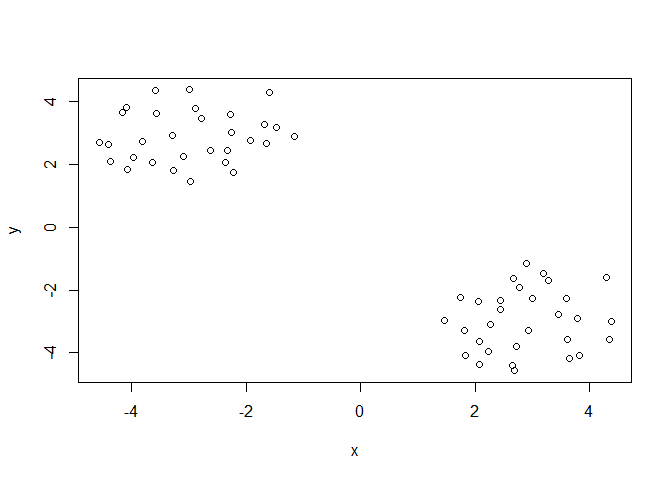

```r
tmp <- c(rnorm(30,-3), rnorm(30,3))
x <- cbind(x=tmp, y=rev(tmp))
plot(x)
```

Try k-means clustering on this data

```r
km <- kmeans(x, centers = 2, nstart = 20)
km
```

```
## K-means clustering with 2 clusters of sizes 30, 30
##
## Cluster means:
##           x         y
## 1  2.873671 -2.969177
## 2 -2.969177  2.873671
##
## Clustering vector:
##  [1] 2 2 2 2 2 2 2 2 2 2 2 2 2 2 2 2 2 2 2 2 2 2 2 2 2 2 2 2 2 2 1 1 1 1 1
## [36] 1 1 1 1 1 1 1 1 1 1 1 1 1 1 1 1 1 1 1 1 1 1 1 1 1
##
## Within cluster sum of squares by cluster:
## [1] 47.18588 47.18588
##  (between_SS / total_SS =  91.6 %)
##
## Available components:
##
## [1] "cluster"      "centers"      "totss"        "withinss"
## [5] "tot.withinss" "betweenss"    "size"         "iter"
## [9] "ifault"
```

How many points are in each cluster

```r
km$size
```

```
## [1] 30 30
```

Print cluster points

```r
km$cluster
```

```
##  [1] 2 2 2 2 2 2 2 2 2 2 2 2 2 2 2 2 2 2 2 2 2 2 2 2 2 2 2 2 2 2 1 1 1 1 1
## [36] 1 1 1 1 1 1 1 1 1 1 1 1 1 1 1 1 1 1 1 1 1 1 1 1 1
```

Print cluster centers

```r
km$centers
```

```
##           x         y
## 1  2.873671 -2.969177
## 2 -2.969177  2.873671
```

Plot x colored by the kmeans cluster assignment Add cluster centers as blue points

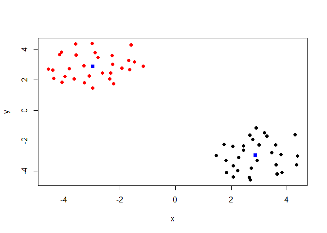

```r
plot(x, col=km$cluster, pch=16)
points(km$centers, col="blue", pch=15)
```

## Hierarchical clustering

First we need to calculate point (dis)similarity as the Euclidean distance between observations

```r
dist_matrix <- dist(x)
```

The hclust() function returns a hierarchicalclustering model

```r
hc <- hclust(d = dist_matrix)
#the print method is not so useful here
hc
```

```
##
## Call:
## hclust(d = dist_matrix)
##
## Cluster method   : complete
## Distance         : euclidean
## Number of objects: 60
```

Try plotting it to see it better

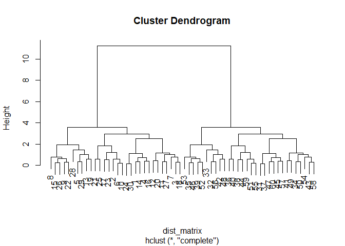

```r
plot(hc)
```

Drawing a dendrogram: cutting the tree to define clusters

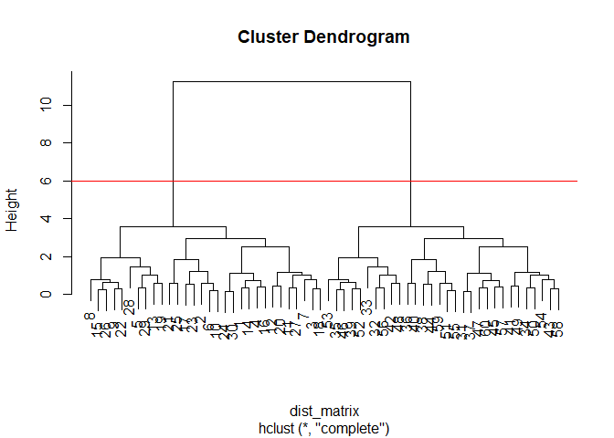

```r
plot(hc)
abline(h=6, col="red")
```

```r
grps <- cutree(hc, k=2 )
table(grps)
```

```
## grps
##  1  2
## 30 30
```

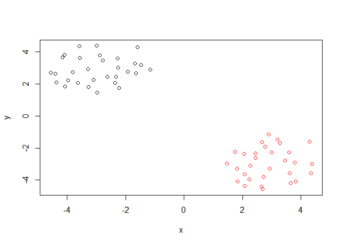

```r
#plot by defined clusters
plot(x, col=grps)
```

Try different cutting

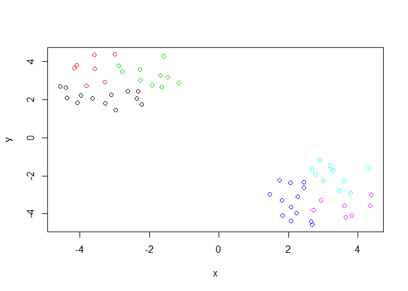

```r
plot(x, col=cutree(hc, k=6))
```

## Practice with HC

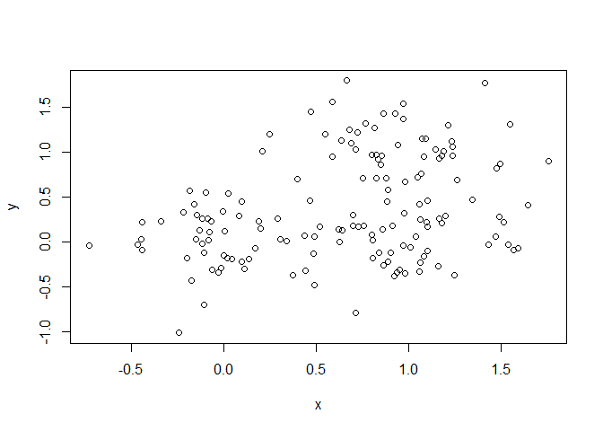

```r
x <- rbind(
 matrix(rnorm(100, mean=0, sd = 0.3), ncol = 2), # c1
 matrix(rnorm(100, mean = 1, sd = 0.3), ncol = 2), # c2
 matrix(c(rnorm(50, mean = 1, sd = 0.3), # c3
 rnorm(50, mean = 0, sd = 0.3)), ncol = 2)
 )
colnames(x) <- c("x", "y")

plot(x)
```

Generate colors for the plot

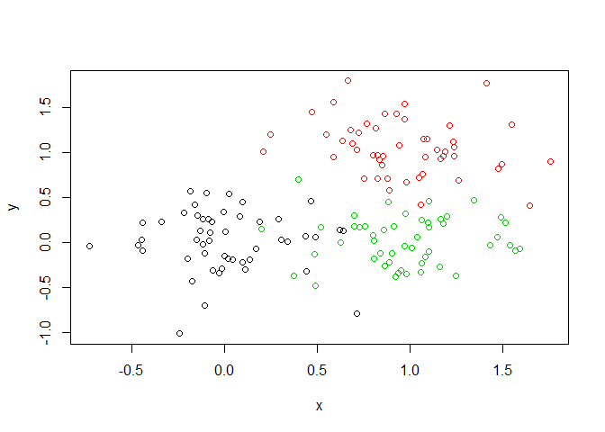

```r
col <- as.factor( rep(c("c1","c2","c3"), each=50) )

plot(x, col=col)
```

## Practicing hierarchical clustering

Use the dist(), hclust(), plot() and cutree() functions to return 2 and 3 clusters

```r
dist_matrix2 <- dist(x) #find distance matrix
hc2 <- hclust(dist_matrix2) #do hierarchical clustering
hc2
```

```
##
## Call:
## hclust(d = dist_matrix2)
##
## Cluster method   : complete
## Distance         : euclidean
## Number of objects: 150
```

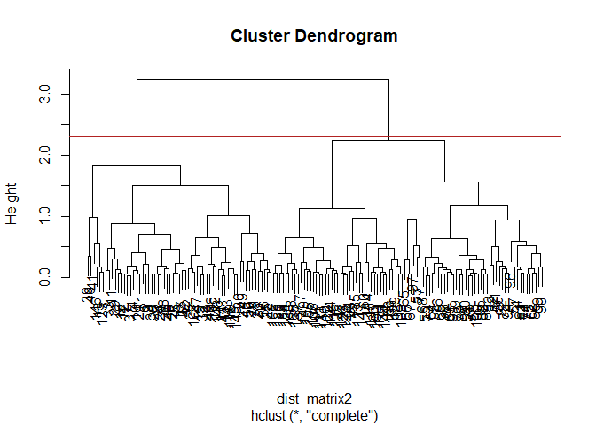

```r
plot(hc2) #print dendrogram for

abline(h=2.3, col="firebrick") #draw a line on the dendrogram
```

```r
grps_k3 <- cutree(hc2, k=3 ) #try to cut this into 3 clusters since
                            #using as.factor we got 3 colors

table(grps_k3) #print this info as a table
```

```
## grps_k3
##  1  2  3
## 61 46 43
```

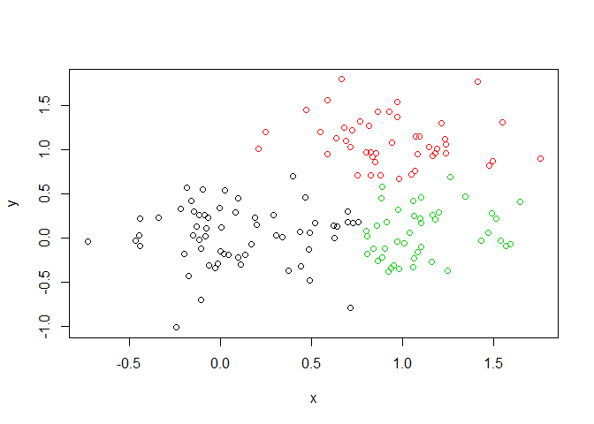

```r
plot(x, col=grps_k3) #visualize this as 3 clusters
```

Try other k

```r
grps_k2 <- cutree(hc2, k=2)
table(grps_k2)
```

```
## grps_k2
##  1  2
## 61 89
```

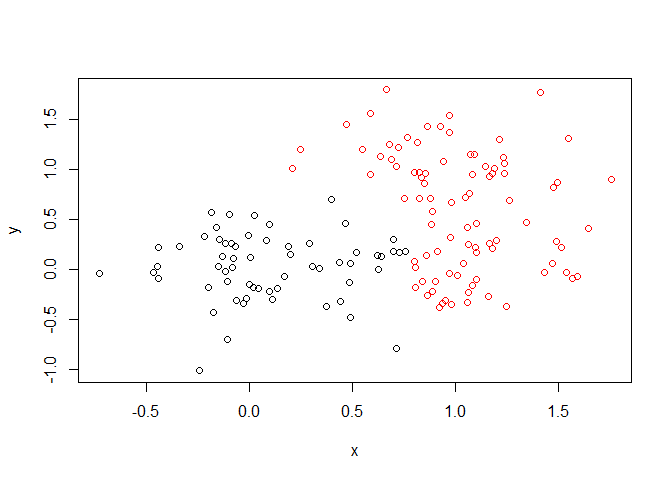

```r
plot(x, col=grps_k2)
```

### Practicing PCA

Import data

```r
mydata <- read.csv('expression.csv',
         row.names=1)
```

Transpose mydata

```r
t(mydata)
```

[output not shown]

[output cut: 55 more lines]

```
## ko2    184    525   1011    589    542    321    583    290    896     85
## ko3    156    518    949    618    507    296    572    319    869     83
## ko4    173    474    947    563    471    332    551    313    841     94
## ko5    161    478    934    574    543    311    591    264    873     70
##     gene92 gene93 gene94 gene95 gene96 gene97 gene98 gene99 gene100
## wt1    853    208    555    527    589    396     33    321      25
## wt2    798    214    584    573    607    384     27    343      34
## wt3    866    200    574    548    579    382     39    349      34
## wt4    843    196    599    548    536    399     42    367      36
## wt5    823    206    581    552    583    401     33    343      32
## ko1    934    409    292    686    497    460    977    949     661
## ko2   1007    408    341    718    479    442   1031    947     685
## ko3    936    403    335    705    479    466   1033    982     678
## ko4    918    368    324    704    467    452   1003   1021     655
## ko5   1005    380    299    677    504    457    974   1010     693
```

Let’s do PCA

```r
pca <- prcomp(t(mydata), scale = TRUE)

attributes(pca)
```

```
## $names
## [1] "sdev"     "rotation" "center"   "scale"    "x"
##
## $class
## [1] "prcomp"
```

Print PCA to see what it looks like, not very useful

```r
pca
```

[output not shown]

[output cut: 253 more lines]

```
## gene86   0.112364288 -0.0825403305
## gene87  -0.073152329  0.0771531312
## gene88   0.322822828 -0.1507531743
## gene89  -0.069259760  0.0869921438
## gene90   0.003756086 -0.0083126612
## gene91   0.003361823  0.0261704675
## gene92   0.203121146 -0.0111935329
## gene93   0.059761246  0.0420842599
## gene94  -0.027522401  0.0724810333
## gene95  -0.006155912  0.1698727958
## gene96   0.357620649 -0.0293725239
## gene97  -0.110509396  0.2989322771
## gene98  -0.008692987 -0.0538474549
## gene99  -0.021081692 -0.0735156379
## gene100  0.022933185 -0.0410250614
```

The returned pca$x here contains the principal components (PCs) for drawing our first graph.

Take first 2 columns in pca$x (PC1 x PC2) to draw a 2D plot

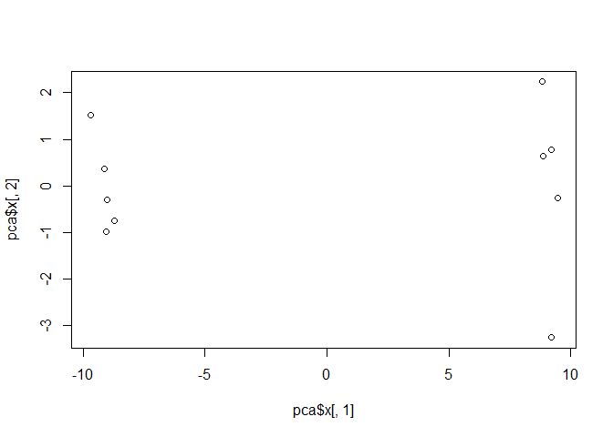

```r
plot(pca$x[,1], pca$x[,2]) #2D plot for PCs
```

```r
pca.var <- pca$sdev^2 #find variance for each PC
pca.var
```

```
##  [1] 9.261625e+01 2.309940e+00 1.119081e+00 1.106773e+00 7.754851e-01
##  [6] 6.813705e-01 6.417798e-01 3.852003e-01 3.641185e-01 1.121154e-29
```

```r
pca.var.per <- round(pca.var/sum(pca.var)*100, 1) # get percent                                                       #variance

pca.var.per
```

```
##  [1] 92.6  2.3  1.1  1.1  0.8  0.7  0.6  0.4  0.4  0.0
```

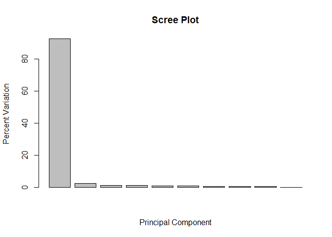

```r
barplot(pca.var.per, main="Scree Plot",
       xlab="Principal Component", ylab="Percent Variation")
```

```r
#barplot of the varianc
#PC1 accounts for almost all of the variation in the data
```

Make the plot more useful

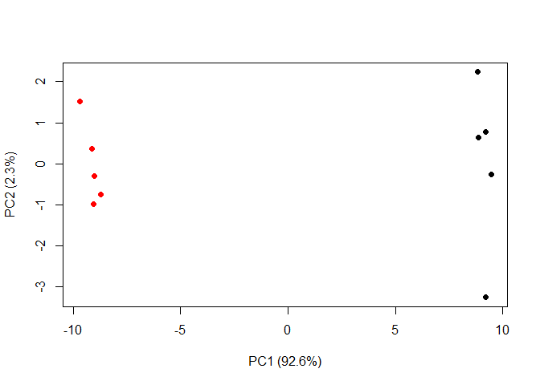

```r
colvec <- as.factor( substr(colnames(mydata), 1, 2))

plot(pca$x[,1], pca$x[,2], col=colvec, pch=16,
     xlab=paste0("PC1 (", pca.var.per[1], "%)"),
     #use paste0 to concentrate vectors after conv to char
     ylab=paste0("PC2 (", pca.var.per[2], "%)"))
```

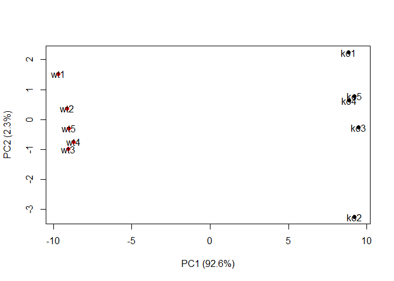

```r
plot(pca$x[,1], pca$x[,2], col=colvec, pch=16,
 xlab=paste0("PC1 (", pca.var.per[1], "%)"),
 ylab=paste0("PC2 (", pca.var.per[2], "%)"))

# use "text" instead of "identify"
#identify points
text(pca$x[,1], pca$x[,2], labels=colnames(mydata))
```

```r
#can use the identify function in console to selectively pick points to identify
```

## Using UK food data

```r
x <- read.csv("UK_foods.csv")
dim(x) #get dimension of data
```

```
## [1] 17  5
```

```r
head(x) #see the first parts of the data
```

```
##                X England Wales Scotland N.Ireland
## 1         Cheese     105   103      103        66
## 2  Carcass_meat      245   227      242       267
## 3    Other_meat      685   803      750       586
## 4           Fish     147   160      122        93
## 5 Fats_and_oils      193   235      184       209
## 6         Sugars     156   175      147       139
```

```r
rownames(x) <- x[,1]
x <- x[,-1] #removes the first column
head(x)
```

```
##                England Wales Scotland N.Ireland
## Cheese             105   103      103        66
## Carcass_meat       245   227      242       267
## Other_meat         685   803      750       586
## Fish               147   160      122        93
## Fats_and_oils      193   235      184       209
## Sugars             156   175      147       139
```

```r
knitr::kable(x, caption="The full UK foods data")
```

The full UK foods data

|  | England | Wales | Scotland | N.Ireland |
| --- | --- | --- | --- | --- |
| Cheese | 105 | 103 | 103 | 66 |
| Carcass_meat | 245 | 227 | 242 | 267 |
| Other_meat | 685 | 803 | 750 | 586 |
| Fish | 147 | 160 | 122 | 93 |
| Fats_and_oils | 193 | 235 | 184 | 209 |
| Sugars | 156 | 175 | 147 | 139 |
| Fresh_potatoes | 720 | 874 | 566 | 1033 |
| Fresh_Veg | 253 | 265 | 171 | 143 |
| Other_Veg | 488 | 570 | 418 | 355 |
| Processed_potatoes | 198 | 203 | 220 | 187 |
| Processed_Veg | 360 | 365 | 337 | 334 |
| Fresh_fruit | 1102 | 1137 | 957 | 674 |
| Cereals | 1472 | 1582 | 1462 | 1494 |
| Beverages | 57 | 73 | 53 | 47 |
| Soft_drinks | 1374 | 1256 | 1572 | 1506 |
| Alcoholic_drinks | 375 | 475 | 458 | 135 |
| Confectionery | 54 | 64 | 62 | 41 |

Generate summary heatmap

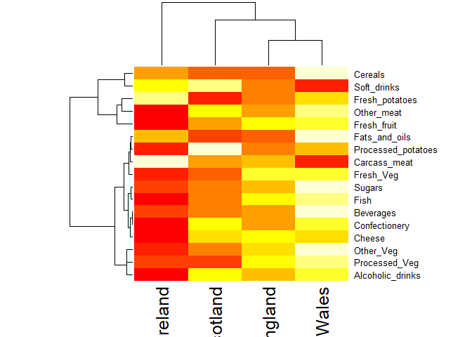

```r
heatmap(as.matrix(x))
```

Use PCA to analyze the data

```r
pca <- prcomp( t(x) ) #use prcomp to do pca
summary(pca) #generate a summary of the pca data
```

```
## Importance of components:
##                             PC1      PC2      PC3       PC4
## Standard deviation     324.1502 212.7478 73.87622 4.189e-14
## Proportion of Variance   0.6744   0.2905  0.03503 0.000e+00
## Cumulative Proportion    0.6744   0.9650  1.00000 1.000e+00
```

Plot PCs

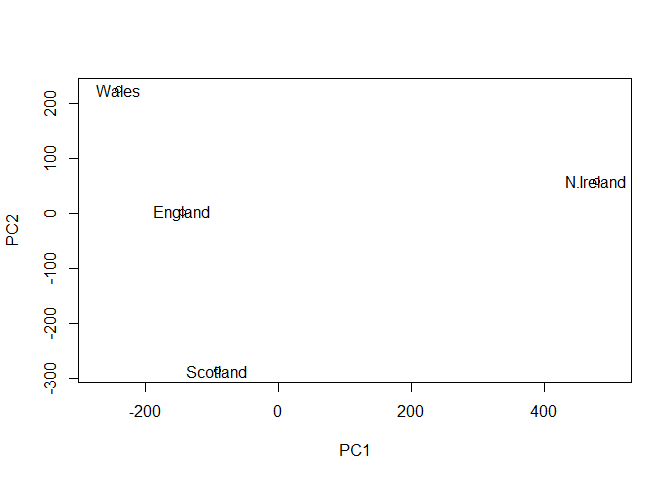

```r
plot(pca$x[,1], pca$x[,2], xlab="PC1", ylab="PC2", xlim=c(-270, 500))

text(pca$x[,1], pca$x[,2], colnames(x))
```